# Very Basic Introduction to C++ and R

C++ is a powerful object-oriented programming language. The initial idea behind C++ was to extend the C language in a flexible way. Also, C++ provides high-level features for program organization. In this brief introduction, we will focus mostly on the similarities of C++ and C and how to integrate it with R using the package [Rcpp](http://www.rcpp.org/).

## Introduction to C++

First, let us start with some basic C++ examples. The very first example is the famous “Hello world!”

### Hello world!

```cpp
#include <iostream>
int main()
{
    std::cout << "Hello, world!\n";
}
```

or yet

```cpp
#include <iostream>
using namespace std;
int main()
{
    cout << "Hello, world!\n";
}
```

In contrast to R, a C++ code needs to be compiled, i.e. the human readable language needs to be translated into a binary code. The reason for this conversion is to create an executable program.

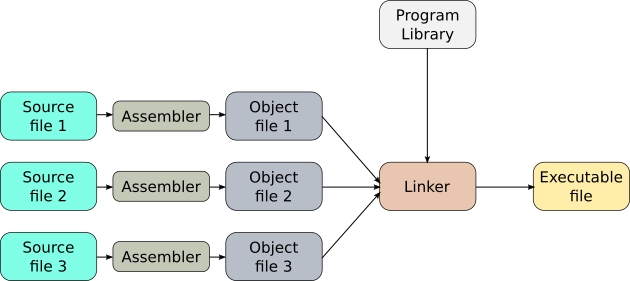

In this turorial, we will use the C++ GNU compiler (g++), which is part of the [**GNU Compiler Collection**](https://gcc.gnu.org/). Usually, a compiler has its own syntax with specific flags. For a very comprehensive list of flags for the GNU Compiler Collection, visit [GCC Preprocessor Options](https://gcc.gnu.org/onlinedocs/gcc-3.4.4/gcc/Preprocessor-Options.html%20"GCC%20Preprocessor%20Options").

```bash
g++ hello.cpp -O2 -Wformat -o hello
```

## The `for` loop

In the next example, a `for` loop is used to print all integer numbers from `a` to `b`:

```cpp
#include <iostream>
using namespace std;
int main()
{
  int a;
  int b;
  cout << "Enter the first number: ";
  cin >> a;
  cout << "\n";
  cout << "Enter the second number: ";
  cin >> b;
  cout << "\n";
  for(a; a < b; a++)
    {
        cout << a << "\n";
    }
}
```

Compiling

```bash
g++ for_example.cpp -O2 -Wformat -o for_exemple
```

### Backcross example

Now, let us write a C++ code to calculate the recombination fraction in a backcross population. The input file is a genotype by marker matrix, with individuals in the rows and markers in the columns.

```cpp
#include <iostream>
#include <vector>
#include <fstream>
#include <string>
#include<iomanip>

using namespace std;
int main()
{


  int n_mar;
  int n_ind;
  double ct;
  cout << "Enter the number of markers: ";
  cin >> n_mar;
  cout << "\n";
  cout << "Enter the number of individuals: ";
  cin >> n_ind;
  cout << "\n";
  string filename;
  ifstream in;
  cout << "Enter the name of the input file ";
  cin >> filename;
  in.open( filename.c_str() );
  if (!in) {
    cout << "Cannot open file.\n";
    return (-1);
  }
  std::vector<std::vector<int> > geno(n_ind, std::vector<int>(n_mar, 0));
  std::vector<std::vector<double> > rec(n_mar, std::vector<double>(n_mar, 0.5));
  for (int i = 0; i < geno.size(); i++) {
    for (int j = 0; j < geno[1].size(); j++) {
      in >> geno[i][j];
    }
  }
  in.close();

  for (int i = 0; i < (n_mar-1); i++)
    {
      for (int j = (i+1); j < n_mar; j++)
    {
      ct=0.0;
      for(int k=0; k < n_ind; k++)
        {
          if(geno[k][i]!=geno[k][j])
        ct++;
        }
      rec[i][j]=ct/n_ind;
    }
    }

  ofstream fout("rec_cpp.txt"); //opening an output stream fo
  for (int i = 0; i < n_mar; i++)
    {
      for (int j = 0; j < n_mar; j++)
    {
      fout << rec[i][j] << " ";
    }
      fout << "\n";
    }
}
```

Compiling and running

```bash
$ g++ bc_est.cpp -O2 -Wformat -o bc_est
$ ./bcest
$ Enter the number of markers: 14
$ Enter the number of individuals: 103
$ Enter the name of the input file mouse.txt
$ cat rec_cpp.txt
```

### Backcross example - R version

```r
dat<-read.table("mouse.txt")
id<-combn(1:ncol(dat),2)
rec<-apply(id, 2, function(x) sum(table(dat[,x[1]],dat[,x[2]])[2:3])/nrow(dat))
names(rec)<-apply(id, 2, paste, collapse="-")
rec
```

## Why integrate C++ and R

### Backcross - a more realistic example

Now let us simulate a backcross example with one chromosome, 250 individuals and 500 markers:

```r
source("simulate_diploid_populations.R")
require(onemap)
dat.bc<-sim.pop.bc(n.ind = 250, n.mrk = 500, ch.len = 200, missing = 0, n.ch = 1, verbose = FALSE)
dat.bc
dat<-dat.bc$geno
write.table(x=dat, file = "fake_bc.txt", row.names = FALSE, col.names = FALSE, quote = FALSE, sep = " ")
```

Using R to obtain the recombination fractions

```r
rec<-matrix(NA,ncol(dat), ncol(dat))
system.time(
  for(i in 1:(ncol(dat)-1)){
    for(j in (i+1):ncol(dat)){
      rec[j,i]<-rec[i,j]<-sum(table(dat[,i], dat[,j])[2:3])/nrow(dat)
    }
  }
)
require(fields)
image.plot(rec, col=rev(tim.colors()))
```

Using our C++ program

```bash
$ ./bcest
$ Enter the number of markers: 500
$ Enter the number of individuals: 250
$ Enter the name of the input file: fake_bc.txt
```

```r
y<-read.table(file = "rec_cpp.txt")
image.plot(as.matrix(y), col=rev(tim.colors()) )
```

## Integrating R and C++

### Resources

There is plenty of resources spread all over the internet on this subject. Here I am going to share some of my favorite. The following figure shows all the packages that depend on, is linked or imports Rcpp:

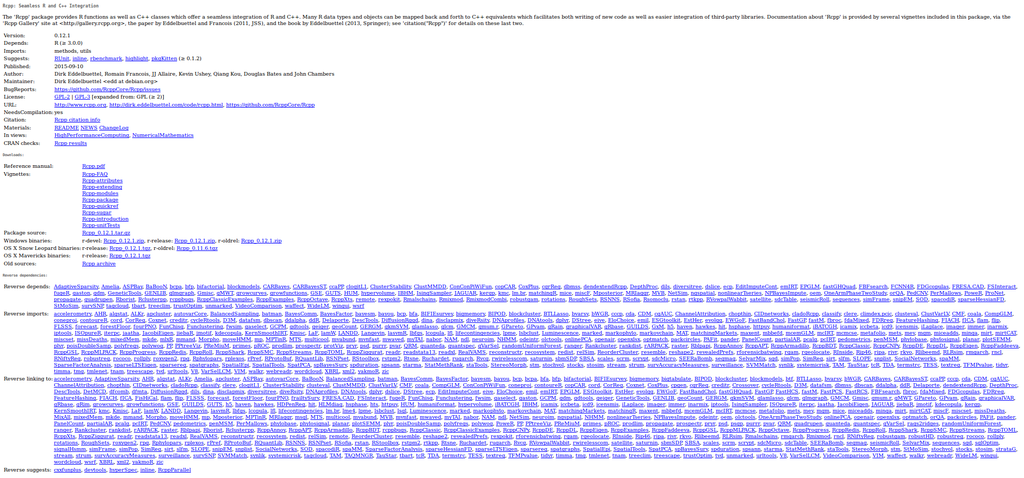

[Dirk Eddelbuettel’s](https://github.com/eddelbuettel) Rcpp book.

[figure not shown]

.

Very useful [Quick reference guide](https://cran.r-project.org/web/packages/Rcpp/vignettes/Rcpp-quickref.pdf).

Let us use it!

### Ways to use Rcpp

There are basically three ways to use RCpp and R: using the package `inline`, using the function `sourceCpp`or embedded into a R package.

#### Using the package `inline`

In R console, write the C++ code and save it in a string. In order to C++ and R communicate to each other, it is necessary to use RCpp constructors, like `Rcpp::NumericMatrix`.

```r
src<-'
    Rcpp::NumericMatrix geno(genoR);
    int n_ind = geno.nrow();
    int n_mar = geno.ncol();
    Rcpp::NumericMatrix rec(n_mar, n_mar);
    double ct;
    for (int i = 0; i < (n_mar-1); i++)
    {
        for (int j = (i+1); j < n_mar; j++)
    {
            ct=0.0;
            for(int k=0; k < n_ind; k++)
        {
                if(geno(k,i)!=geno(k,j))
                    ct++;
                    }
            rec(j,i)=rec(i,j)=ct/n_ind;
    }
    }
    return(rec);
    '
```

Then, we need to compile the program and make it available to R using the following code:

```r
require(Rcpp)
require(inline)
est_bc_inline <- cxxfunction(signature(genoR = "numeric"), body = src, plugin="Rcpp")
```

The compilation process in this case is quite similar to the “pure” C++ compilation; However, instead of generating a executable file, it generates a “shared object” which R is capable to load:

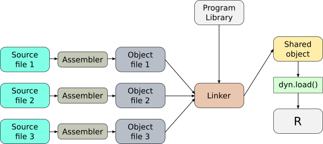

Now, it is just use it:

```r
dat<-as.matrix(read.table("mouse.txt"))
rec<-est_bc_inline(dat)
require(fields)
image.plot(rec, col=rev(tim.colors()))
```

A more realistic example:

```r
##5000 markers
source("simulate_diploid_populations.R")
require(onemap)
dat.bc<-sim.pop.bc(n.ind = 250, n.mrk = 5000, ch.len = 200, missing = 0, n.ch = 1, verbose = FALSE)
dat.bc
dat.bc.t<-dat.bc$geno
system.time(rec<-est_bc_inline(dat.bc.t))
choose(5000, 2)
image.plot(rec, col=rev(tim.colors()))
```